# Modeling Guilty Minds: Omnibus Statistical Analysis

## 3.3 Intraclass Correlations

```r
icc_slider <- compute_icc(d$slider_value, d$pid)
icc_culp   <- compute_icc(d$culpability, d$pid)

deff_slider <- compute_deff(icc_slider)
deff_culp   <- compute_deff(icc_culp)

tibble(
  Measure = c("Risk Slider (0–100)", "Culpability Score (1–4)"),
  ICC     = c(icc_slider, icc_culp),
  `Design Effect` = c(deff_slider, deff_culp),
  `Effective N (trials)` = round(nrow(d) / c(deff_slider, deff_culp))
) %>%
  kable(digits = 3, caption = "Intraclass correlations and design effects") %>%
  kable_styling(bootstrap_options = c("striped", "condensed"), full_width = FALSE)
```

Intraclass correlations and design effects

| Measure | ICC | Design Effect | Effective N (trials) |
| --- | --- | --- | --- |
| Risk Slider (0–100) | 0.287 | 2.147 | 494 |
| Culpability Score (1–4) | 0.162 | 1.650 | 643 |

## 3.4 Demographics

```r
# One row per participant for demographics.
demo <- d %>%
  distinct(pid, age, education, legal_experience) %>%
  filter(!is.na(age))

cat("Age: M =", round(mean(demo$age, na.rm = TRUE), 1),
    ", SD =", round(sd(demo$age, na.rm = TRUE), 1),
    ", range =", min(demo$age, na.rm = TRUE), "-", max(demo$age, na.rm = TRUE), "\n")
```

```
## Age: M = 20.1 , SD = 1.2 , range = 18 - 24
```

```r
cat("\nEducation:\n")
```

```
##
## Education:
```

```r
print(table(demo$education, useNA = "ifany"))
```

```
##
## Bachelor's   Freshman     Junior     Senior  Sophomore
##          5         36         84         40         47
```

```r
cat("\nLegal experience:\n")
```

```
##
## Legal experience:
```

```r
print(table(demo$legal_experience, useNA = "ifany"))
```

```
##
##  No Yes
## 206   6
```

# 4 Hypothesis Tests

## 4.1 H1: Non-Uniform Distribution of Judgments

If participants are merely guessing or treating the four categories as interchangeable, we would expect a uniform distribution (25% per category). H1 predicts systematic deviation from uniformity.

```r
# ── Trial-level chi-square ──
# This is the straightforward test on all trials, but it treats each trial
# as an independent observation. With 5 trials per person and non-trivial
# ICC, the effective sample size is smaller than the raw trial count.

observed <- table(d$judgment)
n_trials <- sum(observed)
expected <- rep(n_trials / 4, 4)

chi_test <- chisq.test(observed, p = rep(0.25, 4))

# Cohen's w: effect size for the chi-square goodness-of-fit test.
# w = sqrt(chi2 / N), but we need to use the DEFF-adjusted N for
# a fair comparison.
cohens_w <- sqrt(chi_test$statistic / n_trials)

# DEFF-adjusted chi-square: the test statistic scales linearly with N,
# so dividing by the design effect gives the corrected statistic.
chi_adj <- chi_test$statistic / deff_culp
p_adj   <- pchisq(chi_adj, df = 3, lower.tail = FALSE)

cat("── H1: Chi-square goodness-of-fit ──\n")
```

```
## ── H1: Chi-square goodness-of-fit ──
```

```r
cat("Observed: ", paste(names(observed), "=", observed, collapse = ", "), "\n")
```

```
## Observed:  Blamelessness = 177, Knowledge = 145, Negligence = 452, Recklessness = 286
```

```r
cat("Expected (uniform): ", round(expected[1]), "each\n\n")
```

```
## Expected (uniform):  265 each
```

```r
cat("Uncorrected:  χ²(3) =", round(chi_test$statistic, 2),
    ", p", fmt_p(chi_test$p.value), "\n")
```

```
## Uncorrected:  χ²(3) = 217.18 , p < .001
```

```r
cat("DEFF-adjusted: χ²(3) =", round(chi_adj, 2),
    ", p", fmt_p(p_adj), "\n")
```

```
## DEFF-adjusted: χ²(3) = 131.67 , p < .001
```

```r
cat("Cohen's w =", fmt_num(cohens_w, 3), "\n")
```

```
## Cohen's w = 0.453
```

```r
# ── Follow-up: pairwise comparisons ──
# Which categories are over- or under-represented relative to 25%?
# We use one-sample proportion tests with Holm correction.

categories <- c("Blamelessness", "Negligence", "Recklessness", "Knowledge")
pairwise_h1 <- map_dfr(categories, function(cat) {
  k   <- sum(d$judgment == cat)
  n   <- nrow(d)
  tst <- prop.test(k, n, p = 0.25)
  tibble(
    Category     = cat,
    Observed_Pct = k / n * 100,
    Expected_Pct = 25,
    Chi2         = tst$statistic,
    p_uncorrected = tst$p.value
  )
}) %>%
  mutate(p_holm = p.adjust(p_uncorrected, method = "holm"))

pairwise_h1 %>%
  kable(digits = c(0, 1, 0, 2, 4, 4),
        caption = "H1 follow-up: each category vs. 25% uniform baseline") %>%
  kable_styling(bootstrap_options = c("striped", "condensed"), full_width = FALSE)
```

H1 follow-up: each category vs. 25% uniform baseline

| Category | Observed_Pct | Expected_Pct | Chi2 | p_uncorrected | p_holm |
| --- | --- | --- | --- | --- | --- |
| Blamelessness | 16.7 | 25 | 38.52 | 0.0000 | 0.0000 |
| Negligence | 42.6 | 25 | 175.01 | 0.0000 | 0.0000 |
| Recklessness | 27.0 | 25 | 2.11 | 0.1459 | 0.1459 |
| Knowledge | 13.7 | 25 | 71.85 | 0.0000 | 0.0000 |

**Interpretation.** Even after correcting for within-subjects clustering via the design effect, the chi-square test is highly significant, confirming that participants do not distribute their judgments uniformly. Negligence is overselected and Knowledge is underselected relative to the uniform baseline. Recklessness is the only category not significantly different from 25%.

## 4.2 H2: Risk Magnitude Predicts Culpability

This is the core prediction of the MPC framework: if participants are sensitive to the legally relevant distinction between mental states, then higher perceived risk should map onto higher culpability judgments.

### 4.2.1 Spearman Correlation

```r
# ── Spearman rank correlation ──
# This is a nonparametric test of the monotonic association between the
# continuous risk slider (0–100) and the ordinal culpability score (1–4).
# Note: this is computed at the trial level and does not account for
# clustering. We report the DEFF-adjusted effective N for context.

rho_test <- cor.test(d$slider_value, d$culpability, method = "spearman",
                     exact = FALSE)

cat("── H2: Spearman correlation ──\n")
```

```
## ── H2: Spearman correlation ──
```

```r
cat("ρ =", fmt_num(rho_test$estimate, 3), "\n")
```

```
## ρ = 0.480
```

```r
cat("S =", round(rho_test$statistic), ", p", fmt_p(rho_test$p.value), "\n")
```

```
## S = 103249996 , p < .001
```

```r
cat("(Trial-level; effective N after DEFF correction ≈",
    round(nrow(d) / deff_slider), ")\n")
```

```
## (Trial-level; effective N after DEFF correction ≈ 494 )
```

### 4.2.2 Cumulative Link Mixed Model: Risk Only

The CLMM is the primary parametric test for H2. It models the ordinal culpability score (1 = Blamelessness through 4 = Knowledge) as a function of the continuous risk slider, with a random intercept for each participant to account for the repeated-measures structure. The CLMM extends standard ordinal logistic regression (proportional odds model) by incorporating random effects that account for the non-independence of observations within participants. A standard ordinal regression would treat all 1,060 trials as independent, ignoring the clustering of 5 trials per person and inflating Type I error rates. The CLMM handles this by estimating participant-specific intercepts, yielding correctly calibrated standard errors and valid inference despite the within-subjects design.

The cumulative link model assumes proportional odds: the effect of risk on the log-odds of being in a higher culpability category is constant across the three threshold transitions (1→2, 2→3, 3→4). This is tested later in the diagnostics section.

```r
# ── Fit the risk-only CLMM ──
m_risk <- clmm(culpability_f ~ slider_value + (1 | pid), data = d)

cat("── H2: Cumulative Link Mixed Model (risk only) ──\n")
```

```
## ── H2: Cumulative Link Mixed Model (risk only) ──
```

```r
summary(m_risk)
```

```
## Cumulative Link Mixed Model fitted with the Laplace approximation
##
## formula: culpability_f ~ slider_value + (1 | pid)
## data:    d
##
##  link  threshold nobs logLik   AIC     niter    max.grad cond.H
##  logit flexible  1060 -1200.48 2410.96 196(593) 2.90e-03 3.3e+04
##
## Random effects:
##  Groups Name        Variance Std.Dev.
##  pid    (Intercept) 0.8719   0.9337
## Number of groups:  pid 212
##
## Coefficients:
##              Estimate Std. Error z value Pr(>|z|)
## slider_value 0.045850   0.003084   14.87   <2e-16 ***
## ---
## Signif. codes:  0 '***' 0.001 '**' 0.01 '*' 0.05 '.' 0.1 ' ' 1
##
## Threshold coefficients:
##     Estimate Std. Error z value
## 1|2  -0.3388     0.1437  -2.358
## 2|3   2.5042     0.1750  14.310
## 3|4   4.4571     0.2172  20.521
```

```r
# Extract and interpret the risk coefficient.
coef_risk <- summary(m_risk)$coefficients
risk_row  <- coef_risk["slider_value", ]

# The raw coefficient is in log-odds per unit change in slider_value.
# Since slider_value ranges 0–100, a one-unit change is small. We also
# compute the standardized coefficient (log-odds per 1 SD of slider).
risk_b   <- risk_row["Estimate"]
risk_se  <- risk_row["Std. Error"]
risk_z   <- risk_row["z value"]
risk_p   <- risk_row["Pr(>|z|)"]
risk_b_std <- risk_b * sd(d$slider_value)

cat("Risk coefficient: b =", fmt_num(risk_b, 4),
    ", SE =", fmt_num(risk_se, 4),
    ", z =", fmt_num(risk_z, 2),
    ", p", fmt_p(risk_p), "\n")
```

```
## Risk coefficient: b = 0.0458 , SE = 0.0031 , z = 14.87 , p < .001
```

```r
cat("Standardized: β =", fmt_num(risk_b_std, 3),
    "(log-odds per 1 SD of slider)\n")
```

```
## Standardized: β = 1.241 (log-odds per 1 SD of slider)
```

```r
cat("Odds ratio per 10-point slider increase:",
    fmt_num(exp(risk_b * 10), 3), "\n")
```

```
## Odds ratio per 10-point slider increase: 1.582
```

### 4.2.3 Predicted Probability Curves

These curves show how the predicted probability of each mental state category changes as a function of the risk slider, holding random effects at zero (i.e., for an “average” participant). We include 95% parametric bootstrap confidence bands computed from the variance-covariance matrix of the CLMM estimates.

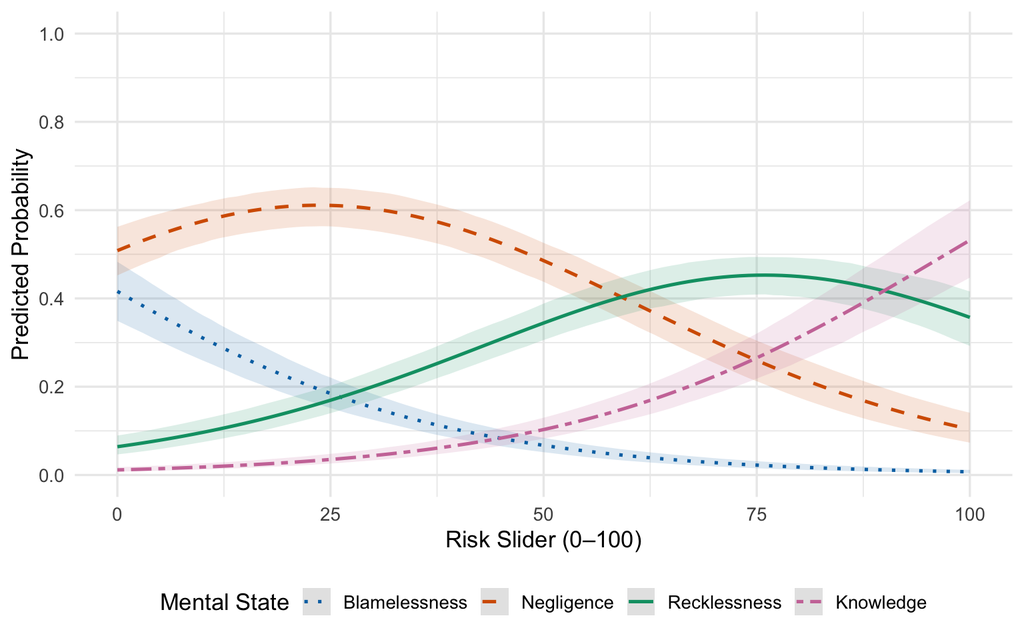

```r
# ── Compute predicted probabilities from the CLMM ──
# The cumulative link model gives us thresholds (α_j) and a slope (β).
# P(Y ≤ j | x) = logistic(α_j - β * x)
# P(Y = j | x) = P(Y ≤ j) - P(Y ≤ j-1)

thresholds <- m_risk$Theta           # three threshold parameters
beta       <- coef(m_risk)["slider_value"]

slider_seq <- seq(0, 100, by = 1)

# ── Point estimates ──
pred_probs <- map_dfr(slider_seq, function(x) {
  cum_probs <- plogis(thresholds - beta * x)
  probs <- c(cum_probs[1],
             cum_probs[2] - cum_probs[1],
             cum_probs[3] - cum_probs[2],
             1 - cum_probs[3])
  tibble(
    slider = x,
    Blamelessness = probs[1],
    Negligence    = probs[2],
    Recklessness  = probs[3],
    Knowledge     = probs[4]
  )
}) %>%
  pivot_longer(-slider, names_to = "judgment", values_to = "probability") %>%
  mutate(judgment = factor(judgment,
    levels = c("Blamelessness","Negligence","Recklessness","Knowledge")))

# ── Parametric bootstrap confidence bands ──
# We draw from the multivariate normal distribution of the estimated
# parameters (thresholds + slope) using the model's variance-covariance
# matrix, then compute predicted probabilities under each draw. The 2.5th
# and 97.5th percentiles across draws give 95% confidence bands.

n_boot <- 1000

# The vcov() method for clmm returns only the fixed-effect vcov (1×1 here).
# The Hessian includes ALL parameters: thresholds, fixed effects, AND the
# random effect variance. We need the joint vcov of just the thresholds
# and fixed effects (first 4 parameters), marginalizing over the random
# effect variance.
param_est <- c(m_risk$Theta, coef(m_risk)["slider_value"])
n_params  <- length(param_est)  # should be 4

# Invert the full Hessian, then extract the submatrix for our 4 parameters.
full_vcov <- solve(m_risk$Hessian)
# The Hessian row/col order is: thresholds, fixed effects, random effects.
# We take only the first n_params rows and columns.
vcov_sub <- full_vcov[1:n_params, 1:n_params]

# Draw parameter samples from the joint multivariate normal.
boot_params <- MASS::mvrnorm(n_boot, mu = param_est, Sigma = vcov_sub)

# For each draw, compute predicted probabilities at each slider value.
boot_probs <- array(NA, dim = c(n_boot, length(slider_seq), 4))
for (b in 1:n_boot) {
  th_b   <- boot_params[b, 1:3]
  beta_b <- boot_params[b, 4]
  for (i in seq_along(slider_seq)) {
    x <- slider_seq[i]
    cum_b <- plogis(th_b - beta_b * x)
    boot_probs[b, i, ] <- c(cum_b[1],
                              cum_b[2] - cum_b[1],
                              cum_b[3] - cum_b[2],
                              1 - cum_b[3])
  }
}

# Extract 2.5% and 97.5% quantiles for each category × slider value.
ci_data <- map_dfr(1:4, function(j) {
  lo <- apply(boot_probs[, , j], 2, quantile, probs = 0.025)
  hi <- apply(boot_probs[, , j], 2, quantile, probs = 0.975)
  tibble(
    slider  = slider_seq,
    ci_lo   = lo,
    ci_hi   = hi,
    judgment = c("Blamelessness","Negligence","Recklessness","Knowledge")[j]
  )
}) %>%
  mutate(judgment = factor(judgment,
    levels = c("Blamelessness","Negligence","Recklessness","Knowledge")))

# Merge point estimates with CIs.
pred_with_ci <- pred_probs %>%
  left_join(ci_data, by = c("slider", "judgment"))

ggplot(pred_with_ci, aes(x = slider, y = probability,
                         color = judgment, linetype = judgment)) +
  geom_ribbon(aes(ymin = ci_lo, ymax = ci_hi, fill = judgment, group = judgment),
              alpha = 0.15, color = NA) +
  geom_line(linewidth = 0.9) +
  scale_color_manual(values = judgment_colors) +
  scale_fill_manual(values = judgment_colors) +
  scale_linetype_manual(values = judgment_linetypes) +
  labs(x = "Risk Slider (0–100)",
       y = "Predicted Probability",
       color = "Mental State", linetype = "Mental State") +
  scale_y_continuous(limits = c(0, 1), breaks = seq(0, 1, 0.2)) +
  scale_x_continuous(breaks = seq(0, 100, 25)) +
  guides(fill = "none") +
  theme_minimal(base_size = 13) +
  theme(legend.position = "bottom")
```

## 4.3 H3: Extralegal Feature Bias

H3 tests whether vignette surface features influence culpability judgments even after controlling for perceived risk. The CLMM from H2 is extended to include all six binary vignette features as fixed effects.

### 4.3.1 Full CLMM: Risk + Features

```r
# ── Fit the full model: risk + all six features ──
# The features are coded 0/1 with the more incriminating level as 1:
#   source_bin:   biker = 1 (vs. uncle)
#   package_bin:  duffel_bag = 1 (vs. gift-wrapped)
#   inquiry_bin:  source_tells = 1 (vs. defendant asks)
#   payment_bin:  $1000 = 1 (vs. none)
#   location_bin: Mexico = 1 (vs. Canada)
#   contents_bin: fentanyl = 1 (vs. rare disease drugs)

m_full <- clmm(
  culpability_f ~ slider_value + source_bin + package_bin + inquiry_bin +
                  payment_bin + location_bin + contents_bin + (1 | pid),
  data = d
)

cat("── H3: Full CLMM (risk + features) ──\n")
```

```
## ── H3: Full CLMM (risk + features) ──
```

```r
summary(m_full)
```

```
## Cumulative Link Mixed Model fitted with the Laplace approximation
##
## formula:
## culpability_f ~ slider_value + source_bin + package_bin + inquiry_bin +
##     payment_bin + location_bin + contents_bin + (1 | pid)
## data:    d
##
##  link  threshold nobs logLik   AIC     niter     max.grad cond.H
##  logit flexible  1060 -1188.69 2399.38 739(2222) 9.08e-03 5.4e+04
##
## Random effects:
##  Groups Name        Variance Std.Dev.
##  pid    (Intercept) 0.9084   0.9531
## Number of groups:  pid 212
##
## Coefficients:
##               Estimate Std. Error z value Pr(>|z|)
## slider_value  0.041489   0.003222  12.878  < 2e-16 ***
## source_bin    0.246756   0.129575   1.904   0.0569 .
## package_bin   0.089592   0.125287   0.715   0.4746
## inquiry_bin  -0.178763   0.124079  -1.441   0.1497
## payment_bin   0.530558   0.135686   3.910 9.22e-05 ***
## location_bin  0.010336   0.124211   0.083   0.9337
## contents_bin -0.229105   0.124227  -1.844   0.0651 .
## ---
## Signif. codes:  0 '***' 0.001 '**' 0.01 '*' 0.05 '.' 0.1 ' ' 1
##
## Threshold coefficients:
##     Estimate Std. Error z value
## 1|2  -0.3196     0.1958  -1.632
## 2|3   2.5819     0.2207  11.700
## 3|4   4.5643     0.2556  17.858
```

```r
# ── Extract feature coefficients ──
coefs <- summary(m_full)$coefficients

# We only want the predictor coefficients, not the thresholds.
predictor_names <- c("slider_value", "source_bin", "package_bin",
                     "inquiry_bin", "payment_bin", "location_bin", "contents_bin")

# Sanity check: verify all expected predictors appear in the model output.
missing <- setdiff(predictor_names, rownames(coefs))
if (length(missing) > 0) {
  cat("WARNING: the following predictors are missing from the model output:\n")
  cat(" ", paste(missing, collapse = ", "), "\n")
  cat("Available coefficient names:", paste(rownames(coefs), collapse = ", "), "\n")
  cat("This usually means a predictor became constant (all 0 or all 1).\n")
  cat("Check factor levels in the data before proceeding.\n\n")
  # Fall back to whatever predictors DO exist so the document can still knit.
  predictor_names <- intersect(predictor_names, rownames(coefs))
}

feature_table <- as_tibble(coefs[predictor_names, ], rownames = "Predictor") %>%
  rename(b = Estimate, SE = `Std. Error`, z = `z value`, p = `Pr(>|z|)`) %>%
  mutate(
    OR = exp(b),
    # Convert log-odds coefficient to approximate Cohen's d using the
    # logistic distribution variance (pi^2/3). For binary predictors,
    # d ≈ b * sqrt(3) / pi.
    d_approx = ifelse(Predictor != "slider_value", b * sqrt(3) / pi, NA)
  )

# ── Holm correction: applied only to the 6 features, not to risk ──
# Risk is tested under H2; the features are a separate family for H3.
feature_only <- feature_table %>% filter(Predictor != "slider_value")
feature_only$p_holm <- p.adjust(feature_only$p, method = "holm")
feature_only <- feature_only %>%
  mutate(Sig = case_when(
    p_holm < .001  ~ "***",
    p_holm < .01   ~ "**",
    p_holm < .05   ~ "*",
    p      < .05   ~ "†",    # uncorrected significant, Holm-corrected not
    TRUE           ~ ""
  ))

risk_only_row <- feature_table %>%
  filter(Predictor == "slider_value") %>%
  mutate(
    p_holm = NA_real_,
    Sig = case_when(p < .001 ~ "***", p < .01 ~ "**", p < .05 ~ "*", TRUE ~ "")
  )

feature_table <- bind_rows(risk_only_row, feature_only)

# Readable labels
feature_table <- feature_table %>%
  mutate(Predictor = recode(Predictor,
    "slider_value" = "Risk Slider",
    "source_bin"   = "Source (biker)",
    "package_bin"  = "Package (duffel bag)",
    "inquiry_bin"  = "Inquiry (source tells)",
    "payment_bin"  = "Payment ($1000)",
    "location_bin" = "Location (Mexico)",
    "contents_bin" = "Contents (fentanyl)"
  ))

feature_table %>%
  dplyr::select(Predictor, b, SE, z, p, OR, d_approx, p_holm, Sig) %>%
  kable(digits = c(0, 3, 3, 2, 4, 3, 3, 4, 0),
        col.names = c("Predictor", "b", "SE", "z", "p", "OR", "d (approx)",
                       "p (Holm)", ""),
        caption = "H3: Full CLMM coefficients († = uncorrected p < .05 only)") %>%
  kable_styling(bootstrap_options = c("striped", "condensed"), full_width = FALSE)
```

H3: Full CLMM coefficients († = uncorrected p < .05 only)

| Predictor | b | SE | z | p | OR | d (approx) | p (Holm) |  |
| --- | --- | --- | --- | --- | --- | --- | --- | --- |
| Risk Slider | 0.041 | 0.003 | 12.88 | 0.0000 | 1.042 | NA | NA | *** |
| Source (biker) | 0.247 | 0.130 | 1.90 | 0.0569 | 1.280 | 0.136 | 0.2843 |  |
| Package (duffel bag) | 0.090 | 0.125 | 0.72 | 0.4746 | 1.094 | 0.049 | 0.9491 |  |
| Inquiry (source tells) | -0.179 | 0.124 | -1.44 | 0.1497 | 0.836 | -0.099 | 0.4490 |  |
| Payment ($1000) | 0.531 | 0.136 | 3.91 | 0.0001 | 1.700 | 0.293 | 0.0006 | *** |
| Location (Mexico) | 0.010 | 0.124 | 0.08 | 0.9337 | 1.010 | 0.006 | 0.9491 |  |
| Contents (fentanyl) | -0.229 | 0.124 | -1.84 | 0.0651 | 0.795 | -0.126 | 0.2843 |  |

**Feature interpretation.** Payment ($1000 vs. none) is the only feature that survives Holm correction, with an odds ratio of 1.70 and an approximate Cohen’s d in the small-to-medium range. Source (biker vs. uncle) shows a marginal trend at the uncorrected level that does not survive multiple comparison correction even with the full sample of 212 participants and 1,060 trials. The remaining four features (package type, inquiry direction, location, and contents) show no meaningful effects, confirming that participants’ mental state attributions are driven primarily by perceived risk and financial motive rather than by geographic stereotypes, outcome severity, or other surface features of the scenario.

### 4.3.2 Forest Plot of Feature Effects

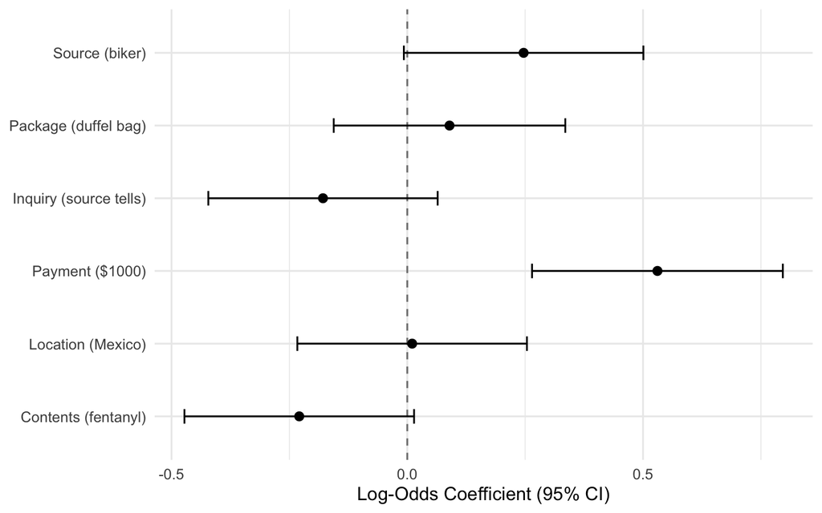

```r
# ── Forest plot: feature coefficients with 95% CIs ──
forest_data <- feature_table %>%
  filter(Predictor != "Risk Slider") %>%
  mutate(
    ci_lo = b - 1.96 * SE,
    ci_hi = b + 1.96 * SE,
    Predictor = factor(Predictor, levels = rev(Predictor))
  )

ggplot(forest_data, aes(x = b, y = Predictor)) +
  geom_vline(xintercept = 0, linetype = "dashed", color = "grey50") +
  geom_errorbarh(aes(xmin = ci_lo, xmax = ci_hi), height = 0.2, linewidth = 0.6) +
  geom_point(size = 2.5) +
  labs(x = "Log-Odds Coefficient (95% CI)", y = NULL) +
  theme_minimal(base_size = 13)
```

### 4.3.3 Model Comparison

```r
# ── Compare nested models ──
# Model 1: risk only (H2)
# Model 2: risk + features (H3)
# The likelihood ratio test tells us whether the features as a group
# add significantly to the model beyond risk alone.

lr_test <- anova(m_risk, m_full)
cat("── Model comparison: risk-only vs. risk + features ──\n")
```

```
## ── Model comparison: risk-only vs. risk + features ──
```

```r
print(lr_test)
```

```
## Likelihood ratio tests of cumulative link models:
##
##        formula:
## m_risk culpability_f ~ slider_value + (1 | pid)
## m_full culpability_f ~ slider_value + source_bin + package_bin + inquiry_bin + payment_bin + location_bin + contents_bin + (1 | pid)
##        link: threshold:
## m_risk logit flexible
## m_full logit flexible
##
##        no.par    AIC  logLik LR.stat df Pr(>Chisq)
## m_risk      5 2411.0 -1200.5
## m_full     11 2399.4 -1188.7  23.581  6  0.0006236 ***
## ---
## Signif. codes:  0 '***' 0.001 '**' 0.01 '*' 0.05 '.' 0.1 ' ' 1
```

### 4.3.4 Random Slopes Model

We also fit a model that allows the risk slope to vary across participants. This is more theoretically complete (different people may weight risk differently), but with only 5 observations per person it may struggle to converge.

```r
# ── Try random slopes for risk ──
# If this doesn't converge, we fall back to random-intercepts-only.
m_full_slopes <- tryCatch({
  clmm(
    culpability_f ~ slider_value + source_bin + package_bin + inquiry_bin +
                    payment_bin + location_bin + contents_bin +
                    (1 + slider_value | pid),
    data = d
  )
}, warning = function(w) {
  cat("Warning during random-slopes fit:", conditionMessage(w), "\n")
  suppressWarnings(
    clmm(
      culpability_f ~ slider_value + source_bin + package_bin + inquiry_bin +
                      payment_bin + location_bin + contents_bin +
                      (1 + slider_value | pid),
      data = d
    )
  )
}, error = function(e) {
  cat("Random slopes model failed to converge:", conditionMessage(e), "\n")
  cat("Falling back to random-intercepts-only model.\n")
  NULL
})

if (!is.null(m_full_slopes)) {
  # ── Check convergence ──
  # The ordinal package stores convergence info in varying field names
  # depending on version. We check several possibilities.
  cat("── Random slopes model ──\n")

  max_grad <- m_full_slopes$maxGradient
  if (!is.numeric(max_grad)) max_grad <- m_full_slopes$info$max.grad
  if (!is.numeric(max_grad)) {
    # Print whatever convergence info we can find
    cat("Convergence info from model:\n")
    str(m_full_slopes$convergence)
    cat("\n")
  } else {
    cat("Max |gradient|:", fmt_num(max_grad, 6), "\n")
    cat("Gradient acceptable (< 1e-03):", max_grad < 1e-03, "\n")
  }
  cat("\n")

  # ── Compare with random-intercepts-only ──
  lr_slopes <- anova(m_full, m_full_slopes)
  print(lr_slopes)

  # ── Random effects variance components ──
  cat("\nRandom effects:\n")
  vc <- VarCorr(m_full_slopes)
  print(vc)

  # ── Interpret the intercept-slope correlation ──
  # A strong negative correlation means that participants who start with
  # higher baseline culpability (harsher judges) show flatter risk slopes:
  # they are less sensitive to variation in perceived risk. Conversely,
  # participants with low baselines (more lenient) show steeper slopes,
  # meaning they differentiate more sharply by risk.
  rs_corr <- tryCatch({
    attr(vc$pid, "correlation")[1, 2]
  }, error = function(e) {
    # If the structure is different, try the correlation matrix directly
    tryCatch(vc$pid[1, 2] / sqrt(vc$pid[1, 1] * vc$pid[2, 2]),
             error = function(e2) NA_real_)
  })

  if (!is.na(rs_corr)) {
    cat("\nIntercept–slope correlation:", fmt_num(rs_corr, 3), "\n")
    if (abs(rs_corr) > 0.85) {
      cat("NOTE: This correlation is very high (|r| > .85), which raises\n")
      cat("concerns about overparameterization. With only 5 observations per\n")
      cat("participant, the random slopes structure may not be estimable with\n")
      cat("precision. The significant LRT improvement indicates meaningfully\n")
      cat("better fit, but the specific variance component estimates should\n")
      cat("be interpreted cautiously. The substantive implication — that\n")
      cat("harsher judges are less risk-sensitive — is a plausible individual\n")
      cat("difference pattern, but the extreme correlation value (|r| > .85)\n")
      cat("suggests the model is likely overparameterized given the limited\n")
      cat("within-person observations. The random-intercepts-only model should\n")
      cat("be preferred for inference on the fixed effects.\n")
    }
  }
} else {
  cat("Random slopes model did not converge. Using random-intercepts-only.\n")
}
```

```
## ── Random slopes model ──
## Convergence info from model:
##  NULL
##
##
## Likelihood ratio tests of cumulative link models:
##
##               formula:
## m_full        culpability_f ~ slider_value + source_bin + package_bin + inquiry_bin + payment_bin + location_bin + contents_bin + (1 | pid)
## m_full_slopes culpability_f ~ slider_value + source_bin + package_bin + inquiry_bin + payment_bin + location_bin + contents_bin + (1 + slider_value | pid)
##               link: threshold:
## m_full        logit flexible
## m_full_slopes logit flexible
##
##               no.par    AIC  logLik LR.stat df Pr(>Chisq)
## m_full            11 2399.4 -1188.7
## m_full_slopes     13 2343.0 -1158.5  60.423  2  7.573e-14 ***
## ---
## Signif. codes:  0 '***' 0.001 '**' 0.01 '*' 0.05 '.' 0.1 ' ' 1
##
## Random effects:
## $pid
##              (Intercept) slider_value
## (Intercept)   5.95323811 -0.091617913
## slider_value -0.09161791  0.001586841
## attr(,"stddev")
##  (Intercept) slider_value
##   2.43992584   0.03983518
## attr(,"correlation")
##              (Intercept) slider_value
## (Intercept)    1.0000000   -0.9426208
## slider_value  -0.9426208    1.0000000
##
##
## Intercept–slope correlation: -0.943
## NOTE: This correlation is very high (|r| > .85), which raises
## concerns about overparameterization. With only 5 observations per
## participant, the random slopes structure may not be estimable with
## precision. The significant LRT improvement indicates meaningfully
## better fit, but the specific variance component estimates should
## be interpreted cautiously. The substantive implication — that
## harsher judges are less risk-sensitive — is a plausible individual
## difference pattern, but the extreme correlation value (|r| > .85)
## suggests the model is likely overparameterized given the limited
## within-person observations. The random-intercepts-only model should
## be preferred for inference on the fixed effects.
```

## 4.4 H4: Risk Distinguishes Recklessness from Knowledge (Exploratory)

Among trials classified as Recklessness or Knowledge, does the risk slider distinguish between them? Under the MPC, Knowledge requires near-certainty of the outcome, while Recklessness requires only awareness of a substantial risk. If participants draw this distinction, Knowledge trials should have higher risk ratings.

```r
# ── Subset to R and K trials ──
d_rk <- d %>%
  filter(judgment %in% c("Recklessness", "Knowledge")) %>%
  mutate(is_knowledge = ifelse(judgment == "Knowledge", 1, 0))

cat("── H4: R vs. K ──\n")
```

```
## ── H4: R vs. K ──
```

```r
cat("Recklessness trials:", sum(d_rk$is_knowledge == 0), "\n")
```

```
## Recklessness trials: 286
```

```r
cat("Knowledge trials:", sum(d_rk$is_knowledge == 1), "\n\n")
```

```
## Knowledge trials: 145
```

```r
# ── Descriptive comparison ──
rk_desc <- d_rk %>%
  group_by(judgment) %>%
  summarise(
    n    = n(),
    mean = mean(slider_value),
    sd   = sd(slider_value),
    se   = sd / sqrt(n),
    .groups = "drop"
  )
print(rk_desc)
```

```
## # A tibble: 2 × 5
##   judgment         n  mean    sd    se
##   <chr>        <int> <dbl> <dbl> <dbl>
## 1 Knowledge      145  51.4  28.6  2.37
## 2 Recklessness   286  59.1  22.3  1.32
```

```r
# ── Linear mixed model ──
# risk ~ is_knowledge + (1 | pid)
# This accounts for the fact that the same participant can contribute
# both R and K trials (for different vignettes).
m_rk <- lmer(slider_value ~ is_knowledge + (1 | pid), data = d_rk)

cat("\n── LMM: slider_value ~ is_knowledge + (1 | pid) ──\n")
```

```
##
## ── LMM: slider_value ~ is_knowledge + (1 | pid) ──
```

```r
summary(m_rk)
```

```
## Linear mixed model fit by REML. t-tests use Satterthwaite's method [
## lmerModLmerTest]
## Formula: slider_value ~ is_knowledge + (1 | pid)
##    Data: d_rk
##
## REML criterion at convergence: 3907.6
##
## Scaled residuals:
##      Min       1Q   Median       3Q      Max
## -3.08489 -0.43342  0.08169  0.56501  2.74954
##
## Random effects:
##  Groups   Name        Variance Std.Dev.
##  pid      (Intercept) 258.9    16.09
##  Residual             343.1    18.52
## Number of obs: 431, groups:  pid, 177
##
## Fixed effects:
##              Estimate Std. Error      df t value Pr(>|t|)
## (Intercept)    58.976      1.720 231.895  34.287  < 2e-16 ***
## is_knowledge   -6.957      2.271 394.019  -3.063  0.00234 **
## ---
## Signif. codes:  0 '***' 0.001 '**' 0.01 '*' 0.05 '.' 0.1 ' ' 1
##
## Correlation of Fixed Effects:
##             (Intr)
## is_knowledg -0.441
```

```r
# Effect size: Cohen's d from the LMM coefficient
rk_coef <- summary(m_rk)$coefficients["is_knowledge", ]
pooled_sd <- sd(d_rk$slider_value)
cohens_d_rk <- rk_coef["Estimate"] / pooled_sd

cat("\nCohen's d =", fmt_num(cohens_d_rk, 3), "\n")
```

```
##
## Cohen's d = -0.281
```

```r
cat("Direction:", ifelse(rk_coef["Estimate"] > 0,
    "Knowledge > Recklessness (expected)",
    "Knowledge < Recklessness (REVERSED)"), "\n")
```

```
## Direction: Knowledge < Recklessness (REVERSED)
```

```r
# ── Two-tailed and one-tailed tests ──
# We preregistered a one-tailed test (Knowledge > Recklessness), but given
# the reversed direction, both tests are reported for transparency.
t_val <- rk_coef["t value"]
df_val <- summary(m_rk)$coefficients["is_knowledge", "df"]
p_two_tailed <- 2 * pt(abs(t_val), df = df_val, lower.tail = FALSE)
p_one_tailed <- pt(t_val, df = df_val, lower.tail = FALSE)

cat("Two-tailed p", fmt_p(p_two_tailed), "\n")
```

```
## Two-tailed p = .002
```

```r
cat("One-tailed p (preregistered: K > R)", fmt_p(p_one_tailed), "\n")
```

```
## One-tailed p (preregistered: K > R) = .999
```

**Interpretation.** The effect is significantly reversed: participants assigned *lower* risk ratings to trials they classified as Knowledge than to those classified as Recklessness. This reversal is consistent with the proportional odds violation documented in the diagnostics section below, where the risk coefficient at the Knowledge threshold is substantially attenuated relative to lower thresholds. Together, these findings indicate that participants’ use of the Knowledge category is not primarily driven by high perceived risk. Rather, Knowledge judgments appear to be triggered by qualitative features of the vignettes (most notably payment) or by a categorical inference about the defendant’s state of mind that is not captured by the continuous risk slider. With 286 Recklessness and 145 Knowledge trials, this reversal is robust and unlikely to be an artifact of insufficient power.

# 5 Secondary and Exploratory Analyses

## 5.1 MPC Ranking Accuracy

After the five vignette trials, participants ranked the four mental state definitions from most to least culpable. We test whether they can recover the correct MPC ordering when the definitions are presented side by side.

```r
cat("── MPC Ranking Accuracy ──\n")
```

```
## ── MPC Ranking Accuracy ──
```

```r
cat("Participants with ranking data:", nrow(ranking_data), "\n")
```

```
## Participants with ranking data: 212
```

```r
cat("Exact correct (K > R > N > B):", sum(ranking_data$exact_match),
    "(", round(mean(ranking_data$exact_match) * 100, 1), "%)\n")
```

```
## Exact correct (K > R > N > B): 86 ( 40.6 %)
```

```r
cat("Endpoints correct (K first, B last):", sum(ranking_data$endpoints_correct),
    "(", round(mean(ranking_data$endpoints_correct) * 100, 1), "%)\n")
```

```
## Endpoints correct (K first, B last): 87 ( 41 %)
```

```r
# ── Binomial test against chance ──
# With 4 items, there are 4! = 24 possible orderings. Chance = 1/24 ≈ 4.17%.
n_correct <- sum(ranking_data$exact_match)
n_total   <- nrow(ranking_data)
binom_test <- binom.test(n_correct, n_total, p = 1/24, alternative = "greater")

cat("\nBinomial test (exact match vs. chance = 4.17%):\n")
```

```
##
## Binomial test (exact match vs. chance = 4.17%):
```

```r
cat("  Observed:", n_correct, "/", n_total,
    "(", round(n_correct / n_total * 100, 1), "%)\n")
```

```
##   Observed: 86 / 212 ( 40.6 %)
```

```r
cat("  p", fmt_p(binom_test$p.value), "\n")
```

```
##   p < .001
```

```r
cat("  95% CI:", round(binom_test$conf.int[1] * 100, 1), "% –",
    round(binom_test$conf.int[2] * 100, 1), "%\n")
```

```
##   95% CI: 34.9 % – 100 %
```

```r
# ── Endpoints binomial test ──
# Chance of getting both endpoints right by chance:
# P(K first) = 1/4, P(B last | K first) = 1/3, so P(both) = 1/12 ≈ 8.33%.
n_endpoints <- sum(ranking_data$endpoints_correct)
binom_endpoints <- binom.test(n_endpoints, n_total, p = 1/12, alternative = "greater")

cat("\nEndpoints test (K first & B last vs. chance = 8.33%):\n")
```

```
##
## Endpoints test (K first & B last vs. chance = 8.33%):
```

```r
cat("  Observed:", n_endpoints, "/", n_total,
    "(", round(n_endpoints / n_total * 100, 1), "%)\n")
```

```
##   Observed: 87 / 212 ( 41 %)
```

```r
cat("  p", fmt_p(binom_endpoints$p.value), "\n")
```

```
##   p < .001
```

```r
# ── Kendall's tau for each participant ──
# This gives a continuous measure of how close each participant's ranking
# is to the correct ordering, rather than the all-or-nothing exact match.

correct_numeric <- c("Knowledge" = 1, "Recklessness" = 2,
                     "Negligence" = 3, "Blamelessness" = 4)

ranking_data <- ranking_data %>%
  mutate(
    participant_numeric = map(ranking, ~ correct_numeric[.x]),
    tau = map_dbl(participant_numeric, ~ cor(.x, 1:4, method = "kendall"))
  )

cat("── Kendall's τ ──\n")
```

```
## ── Kendall's τ ──
```

```r
cat("Mean τ:", fmt_num(mean(ranking_data$tau), 3), "\n")
```

```
## Mean τ: 0.623
```

```r
cat("SD τ:", fmt_num(sd(ranking_data$tau), 3), "\n")
```

```
## SD τ: 0.504
```

```r
# Test whether the mean tau is significantly above zero (random ranking).
tau_test <- t.test(ranking_data$tau, mu = 0, alternative = "greater")
cat("One-sample t-test (H0: τ = 0):\n")
```

```
## One-sample t-test (H0: τ = 0):
```

```r
cat("  t(", tau_test$parameter, ") =", fmt_num(tau_test$statistic, 2),
    ", p", fmt_p(tau_test$p.value), "\n")
```

```
##   t( 211 ) = 17.99 , p < .001
```

## 5.2 RPM and Cognitive Ability Moderation

Does cognitive ability (proxied by Raven’s Progressive Matrices performance) moderate the relationship between risk perception and culpability judgment?

```r
cat("── RPM Descriptives ──\n")
```

```
## ── RPM Descriptives ──
```

```r
cat("Mean correct:", fmt_num(mean(rpm_data$rpm_correct, na.rm = TRUE), 2),
    "out of", rpm_data$rpm_total[1], "\n")
```

```
## Mean correct: 3.34 out of 5
```

```r
cat("SD:", fmt_num(sd(rpm_data$rpm_correct, na.rm = TRUE), 2), "\n")
```

```
## SD: 1.47
```

```r
cat("Range:", min(rpm_data$rpm_correct, na.rm = TRUE), "–",
    max(rpm_data$rpm_correct, na.rm = TRUE), "\n")
```

```
## Range: 0 – 5
```

```r
# ── CLMM with RPM interaction ──
# risk * rpm_prop tests whether the risk–culpability slope is steeper
# for participants with higher cognitive ability.

# Center RPM for interpretability
d <- d %>%
  mutate(rpm_c = rpm_prop - mean(rpm_prop, na.rm = TRUE))

m_rpm <- clmm(
  culpability_f ~ slider_value * rpm_c + source_bin + package_bin +
                  inquiry_bin + payment_bin + location_bin + contents_bin +
                  (1 | pid),
  data = d %>% filter(!is.na(rpm_c))
)

cat("── RPM × Risk Interaction ──\n")
```

```
## ── RPM × Risk Interaction ──
```

```r
summary(m_rpm)
```

```
## Cumulative Link Mixed Model fitted with the Laplace approximation
##
## formula: culpability_f ~ slider_value * rpm_c + source_bin + package_bin +
##     inquiry_bin + payment_bin + location_bin + contents_bin +      (1 | pid)
## data:    d %>% filter(!is.na(rpm_c))
##
##  link  threshold nobs logLik   AIC     niter      max.grad cond.H
##  logit flexible  1060 -1186.89 2399.79 1154(3467) 3.09e-02 8.8e+04
##
## Random effects:
##  Groups Name        Variance Std.Dev.
##  pid    (Intercept) 0.8857   0.9411
## Number of groups:  pid 212
##
## Coefficients:
##                      Estimate Std. Error z value Pr(>|z|)
## slider_value        0.0416160  0.0032158  12.941  < 2e-16 ***
## rpm_c              -0.5572603  0.4766774  -1.169 0.242383
## source_bin          0.2468532  0.1297271   1.903 0.057058 .
## package_bin         0.0852772  0.1252136   0.681 0.495837
## inquiry_bin        -0.1787352  0.1240645  -1.441 0.149680
## payment_bin         0.5252493  0.1357559   3.869 0.000109 ***
## location_bin        0.0124514  0.1242250   0.100 0.920160
## contents_bin       -0.2231335  0.1242411  -1.796 0.072499 .
## slider_value:rpm_c -0.0003953  0.0089462  -0.044 0.964756
## ---
## Signif. codes:  0 '***' 0.001 '**' 0.01 '*' 0.05 '.' 0.1 ' ' 1
##
## Threshold coefficients:
##     Estimate Std. Error z value
## 1|2  -0.3189     0.1956  -1.631
## 2|3   2.5851     0.2206  11.719
## 3|4   4.5687     0.2555  17.881
```

```r
# Test the interaction term specifically.
rpm_coefs <- summary(m_rpm)$coefficients
if ("slider_value:rpm_c" %in% rownames(rpm_coefs)) {
  interaction_row <- rpm_coefs["slider_value:rpm_c", ]
  cat("\nInteraction (slider × RPM):\n")
  cat("  b =", fmt_num(interaction_row["Estimate"], 4),
      ", z =", fmt_num(interaction_row["z value"], 2),
      ", p", fmt_p(interaction_row["Pr(>|z|)"]), "\n")
  if (abs(interaction_row["Pr(>|z|)"]) > .05) {
    cat("  Interpretation: The interaction is not significant, indicating\n")
    cat("  that cognitive ability (RPM) does not moderate the relationship\n")
    cat("  between risk perception and culpability judgment.\n")
  } else if (interaction_row["Estimate"] > 0) {
    cat("  Interpretation: The positive interaction means higher-RPM participants\n")
    cat("  show a steeper risk–culpability slope — they differentiate more\n")
    cat("  sharply between mental states on the basis of perceived risk.\n")
  } else {
    cat("  Interpretation: The negative interaction means higher-RPM participants\n")
    cat("  show a shallower risk–culpability slope — they differentiate less\n")
    cat("  sharply between mental states on the basis of perceived risk.\n")
  }
} else {
  cat("\nWARNING: slider_value:rpm_c interaction not found in model output.\n")
  cat("Available terms:", paste(rownames(rpm_coefs), collapse = ", "), "\n")
}
```

```
##
## Interaction (slider × RPM):
##   b = -0.0004 , z = -0.04 , p = .965
##   Interpretation: The interaction is not significant, indicating
##   that cognitive ability (RPM) does not moderate the relationship
##   between risk perception and culpability judgment.
```

```r
# ── Does RPM predict ranking accuracy? ──
ranking_rpm <- ranking_data %>%
  left_join(rpm_data, by = "pid") %>%
  filter(!is.na(rpm_prop))

# Point-biserial correlation: RPM proportion correct × exact match
if (sum(ranking_rpm$exact_match) > 2) {
  rpm_rank_cor <- cor.test(ranking_rpm$rpm_prop,
                           as.numeric(ranking_rpm$exact_match))
  cat("RPM × exact ranking match: r =", fmt_num(rpm_rank_cor$estimate, 3),
      ", p", fmt_p(rpm_rank_cor$p.value), "\n")
}
```

```
## RPM × exact ranking match: r = 0.005 , p = .940
```

```r
# Correlation with Kendall's tau (continuous ranking quality)
rpm_tau_cor <- cor.test(ranking_rpm$rpm_prop, ranking_rpm$tau)
cat("RPM × Kendall's τ: r =", fmt_num(rpm_tau_cor$estimate, 3),
    ", p", fmt_p(rpm_tau_cor$p.value), "\n")
```

```
## RPM × Kendall's τ: r = 0.146 , p = .034
```

## 5.3 Individual Differences Clustering

We look for participant-level profiles that might reveal distinct “types” of judgment strategy (e.g., consistently harsh, consistently lenient, risk-calibrated, or random-looking).

```r
# ── Build participant-level feature vectors ──
participant_profiles <- d %>%
  group_by(pid) %>%
  summarise(
    # Judgment distribution: proportion of trials in each category
    pct_B = mean(judgment == "Blamelessness"),
    pct_N = mean(judgment == "Negligence"),
    pct_R = mean(judgment == "Recklessness"),
    pct_K = mean(judgment == "Knowledge"),
    # Mean and SD of risk slider
    mean_risk = mean(slider_value),
    sd_risk   = sd(slider_value),
    # Within-person risk-culpability correlation
    rho_risk_culp = cor(slider_value, culpability, method = "spearman"),
    .groups = "drop"
  ) %>%
  left_join(ranking_data %>% dplyr::select(pid, tau, exact_match), by = "pid") %>%
  left_join(rpm_data %>% dplyr::select(pid, rpm_prop), by = "pid") %>%
  mutate(across(where(is.numeric), ~ replace_na(.x, 0)))

# ── K-means clustering ──
# We use the judgment proportions + mean risk + rho as the clustering features.
# RPM and tau are held out as validation variables.
cluster_vars <- participant_profiles %>%
  dplyr::select(pct_B, pct_N, pct_R, pct_K, mean_risk, rho_risk_culp) %>%
  scale()

# Determine optimal k using the silhouette method.
sil_results <- map_dbl(2:6, function(k) {
  km <- kmeans(cluster_vars, centers = k, nstart = 25, iter.max = 100)
  mean(silhouette(km$cluster, dist(cluster_vars))[, "sil_width"])
})

optimal_k <- which.max(sil_results) + 1  # +1 because we started at k=2
cat("Silhouette widths for k = 2 through 6:", round(sil_results, 3), "\n")
```

```
## Silhouette widths for k = 2 through 6: 0.209 0.216 0.246 0.253 0.232
```

```r
cat("Optimal k:", optimal_k, "\n")
```

```
## Optimal k: 5
```

```r
# ── Fit the chosen k-means model ──
km_fit <- kmeans(cluster_vars, centers = optimal_k, nstart = 25, iter.max = 100)
participant_profiles$cluster <- factor(km_fit$cluster)

# ── Cluster summary ──
cluster_summary <- participant_profiles %>%
  group_by(cluster) %>%
  summarise(
    n = n(),
    mean_B = mean(pct_B), mean_N = mean(pct_N),
    mean_R = mean(pct_R), mean_K = mean(pct_K),
    mean_risk = mean(mean_risk),
    mean_rho  = mean(rho_risk_culp),
    mean_tau  = mean(tau, na.rm = TRUE),
    mean_rpm  = mean(rpm_prop, na.rm = TRUE),
    .groups = "drop"
  )

cluster_summary %>%
  kable(digits = 2, caption = paste("K-means cluster profiles (k =", optimal_k, ")")) %>%
  kable_styling(bootstrap_options = c("striped", "condensed"), full_width = FALSE)
```

K-means cluster profiles (k = 5 )

| cluster | n | mean_B | mean_N | mean_R | mean_K | mean_risk | mean_rho | mean_tau | mean_rpm |
| --- | --- | --- | --- | --- | --- | --- | --- | --- | --- |
| 1 | 60 | 0.08 | 0.36 | 0.53 | 0.04 | 49.87 | 0.67 | 0.66 | 0.69 |
| 2 | 45 | 0.09 | 0.79 | 0.08 | 0.04 | 25.84 | 0.33 | 0.65 | 0.68 |
| 3 | 35 | 0.55 | 0.28 | 0.11 | 0.05 | 30.99 | 0.59 | 0.68 | 0.74 |
| 4 | 42 | 0.11 | 0.40 | 0.15 | 0.33 | 46.92 | 0.67 | 0.61 | 0.66 |
| 5 | 30 | 0.09 | 0.21 | 0.39 | 0.31 | 48.99 | -0.47 | 0.46 | 0.54 |

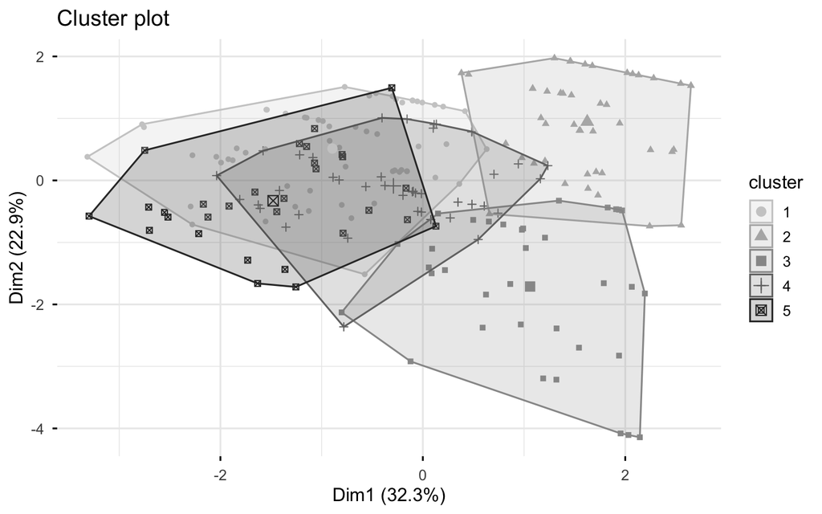

```r
# ── PCA-based visualization of clusters ──
fviz_cluster(km_fit, data = cluster_vars,
             geom = "point", ellipse = TRUE,
             ellipse.type = "convex",
             palette = "grey",
             ggtheme = theme_minimal(base_size = 13))
```

## 5.4 Risk Magnitude Mediation (Exploratory)

Does risk magnitude mediate the effect of vignette features on culpability? That is, do features influence judgments by changing perceived risk, or do they have direct effects beyond what risk explains?

The simplest test: compare feature coefficients in a model without risk (direct + indirect effects combined) versus a model with risk (direct effects only). A substantial reduction in feature coefficients when risk is added suggests mediation.

```r
# ── Model without risk: features only ──
m_features_only <- clmm(
  culpability_f ~ source_bin + package_bin + inquiry_bin +
                  payment_bin + location_bin + contents_bin + (1 | pid),
  data = d
)

# ── Compare feature coefficients: with vs. without risk ──
coef_no_risk <- summary(m_features_only)$coefficients
coef_w_risk  <- summary(m_full)$coefficients

feature_names <- c("source_bin", "package_bin", "inquiry_bin",
                   "payment_bin", "location_bin", "contents_bin")
feature_labels <- c("Source", "Package", "Inquiry",
                    "Payment", "Location", "Contents")

mediation_table <- tibble(
  Feature = feature_labels,
  b_total  = coef_no_risk[feature_names, "Estimate"],
  b_direct = coef_w_risk[feature_names, "Estimate"],
  reduction_pct = (1 - b_direct / b_total) * 100
)

mediation_table %>%
  kable(digits = c(0, 3, 3, 1),
        col.names = c("Feature", "b (no risk)", "b (with risk)", "% reduction"),
        caption = "Mediation check: coefficient reduction when risk is added") %>%
  kable_styling(bootstrap_options = c("striped", "condensed"), full_width = FALSE)
```

Mediation check: coefficient reduction when risk is added

| Feature | b (no risk) | b (with risk) | % reduction |
| --- | --- | --- | --- |
| Source | 0.684 | 0.247 | 63.9 |
| Package | 0.257 | 0.090 | 65.2 |
| Inquiry | -0.219 | -0.179 | 18.3 |
| Payment | 1.085 | 0.531 | 51.1 |
| Location | 0.001 | 0.010 | -614.0 |
| Contents | -0.176 | -0.229 | -30.1 |

```r
# ── Exploratory: do very low slider values function as "no awareness"? ──
# The MPC distinguishes negligence (failure to perceive risk) from
# recklessness (conscious disregard of perceived risk). If participants
# use the low end of the slider to indicate non-awareness, we should see
# an elevated proportion of Blamelessness and Negligence judgments at
# very low slider values.

d <- d %>%
  mutate(low_risk = slider_value <= 10)

low_risk_table <- d %>%
  group_by(low_risk) %>%
  count(judgment) %>%
  mutate(pct = n / sum(n) * 100) %>%
  dplyr::select(-n) %>%
  pivot_wider(names_from = judgment, values_from = pct, values_fill = 0)

cat("── Judgment distribution by slider range ──\n")
```

```
## ── Judgment distribution by slider range ──
```

```r
low_risk_table %>%
  mutate(low_risk = ifelse(low_risk, "Slider ≤ 10", "Slider > 10")) %>%
  kable(digits = 1, caption = "Judgment proportions for low vs. higher risk ratings") %>%
  kable_styling(bootstrap_options = c("striped", "condensed"), full_width = FALSE)
```

Judgment proportions for low vs. higher risk ratings

| low_risk | Blamelessness | Knowledge | Negligence | Recklessness |
| --- | --- | --- | --- | --- |
| Slider > 10 | 11.0 | 14.6 | 42.7 | 31.8 |
| Slider ≤ 10 | 43.1 | 9.6 | 42.6 | 4.8 |

## 5.5 Order and Learning Effects

Do judgments shift across the five vignettes within a session? If participants are learning from the task or developing a response strategy, we might see systematic position effects.

```r
# ── Mean culpability by presentation position ──
position_summary <- d %>%
  group_by(position) %>%
  summarise(
    mean_culp = mean(culpability),
    se_culp   = sd(culpability) / sqrt(n()),
    mean_risk = mean(slider_value),
    se_risk   = sd(slider_value) / sqrt(n()),
    .groups = "drop"
  )

position_summary %>%
  kable(digits = 2, caption = "Mean culpability and risk by presentation position") %>%
  kable_styling(bootstrap_options = c("striped", "condensed"), full_width = FALSE)
```

Mean culpability and risk by presentation position

| position | mean_culp | se_culp | mean_risk | se_risk |
| --- | --- | --- | --- | --- |
| 1 | 2.25 | 0.05 | 35.93 | 1.78 |
| 2 | 2.40 | 0.07 | 43.78 | 1.81 |
| 3 | 2.45 | 0.06 | 41.24 | 1.85 |
| 4 | 2.45 | 0.07 | 39.33 | 1.91 |
| 5 | 2.33 | 0.06 | 44.45 | 1.91 |

```r
# ── Test position as a predictor in the CLMM ──
m_position <- clmm(
  culpability_f ~ slider_value + position + (1 | pid),
  data = d
)

pos_coef <- summary(m_position)$coefficients["position", ]
cat("Position effect in CLMM: b =", fmt_num(pos_coef["Estimate"], 3),
    ", z =", fmt_num(pos_coef["z value"], 2),
    ", p", fmt_p(pos_coef["Pr(>|z|)"]), "\n")
```

```
## Position effect in CLMM: b = -0.007 , z = -0.17 , p = .864
```

# 6 Model Diagnostics

## 6.1 Proportional Odds Assumption

The CLMM assumes proportional odds: the effect of each predictor on the log-odds is the same across all three threshold transitions. A violation would mean, for example, that risk matters more for the transition from Negligence to Recklessness than for Blamelessness to Negligence.

We test this by fitting separate binary logistic models at each threshold and comparing the risk coefficients. If they are roughly similar, the assumption holds.

```r
# ── Threshold-specific models ──
# Create binary outcomes at each threshold:
#   Y1: culpability >= 2 (Negligence or higher vs. Blamelessness)
#   Y2: culpability >= 3 (Recklessness or higher vs. Negligence or lower)
#   Y3: culpability >= 4 (Knowledge vs. everything else)

d <- d %>%
  mutate(
    y_ge2 = as.integer(culpability >= 2),
    y_ge3 = as.integer(culpability >= 3),
    y_ge4 = as.integer(culpability >= 4)
  )

# Fit a logistic mixed model at each threshold.
m_t1 <- glmer(y_ge2 ~ slider_value + (1 | pid), data = d, family = binomial,
              control = glmerControl(optimizer = "bobyqa"))
m_t2 <- glmer(y_ge3 ~ slider_value + (1 | pid), data = d, family = binomial,
              control = glmerControl(optimizer = "bobyqa"))
m_t3 <- glmer(y_ge4 ~ slider_value + (1 | pid), data = d, family = binomial,
              control = glmerControl(optimizer = "bobyqa"))

# Compare the risk coefficients.
threshold_coefs <- tibble(
  Threshold = c("≥ Negligence (1→2+)", "≥ Recklessness (2→3+)", "≥ Knowledge (3→4)"),
  b_risk = c(fixef(m_t1)["slider_value"],
             fixef(m_t2)["slider_value"],
             fixef(m_t3)["slider_value"]),
  SE = c(sqrt(vcov(m_t1)["slider_value","slider_value"]),
         sqrt(vcov(m_t2)["slider_value","slider_value"]),
         sqrt(vcov(m_t3)["slider_value","slider_value"]))
) %>%
  mutate(
    ci_lo = b_risk - 1.96 * SE,
    ci_hi = b_risk + 1.96 * SE
  )

threshold_coefs %>%
  kable(digits = 4,
        col.names = c("Threshold", "b (risk)", "SE", "95% CI lo", "95% CI hi"),
        caption = "Risk coefficient at each threshold (proportional odds check)") %>%
  kable_styling(bootstrap_options = c("striped", "condensed"), full_width = FALSE)
```

Risk coefficient at each threshold (proportional odds check)

| Threshold | b (risk) | SE | 95% CI lo | 95% CI hi |
| --- | --- | --- | --- | --- |
| ≥ Negligence (1→2+) | 0.0591 | 0.0064 | 0.0465 | 0.0717 |
| ≥ Recklessness (2→3+) | 0.0518 | 0.0041 | 0.0437 | 0.0599 |
| ≥ Knowledge (3→4) | 0.0185 | 0.0039 | 0.0109 | 0.0261 |

```r
# ── Formal assessment ──
# The proportional odds assumption requires these three coefficients to be
# approximately equal. We check whether their 95% CIs overlap.

cat("── Proportional odds diagnostic ──\n")
```

```
## ── Proportional odds diagnostic ──
```

```r
cat("Risk coefficient at Threshold 1 (≥ Negligence):   ",
    fmt_num(threshold_coefs$b_risk[1], 4), "\n")
```

```
## Risk coefficient at Threshold 1 (≥ Negligence):    0.0591
```

```r
cat("Risk coefficient at Threshold 2 (≥ Recklessness): ",
    fmt_num(threshold_coefs$b_risk[2], 4), "\n")
```

```
## Risk coefficient at Threshold 2 (≥ Recklessness):  0.0518
```

```r
cat("Risk coefficient at Threshold 3 (≥ Knowledge):    ",
    fmt_num(threshold_coefs$b_risk[3], 4), "\n\n")
```

```
## Risk coefficient at Threshold 3 (≥ Knowledge):     0.0185
```

```r
# Ratio of smallest to largest coefficient
ratio_3_1 <- threshold_coefs$b_risk[3] / threshold_coefs$b_risk[1]
cat("Ratio (Threshold 3 / Threshold 1):", fmt_num(ratio_3_1, 3), "\n\n")
```

```
## Ratio (Threshold 3 / Threshold 1): 0.313
```

```r
# Do CIs of Threshold 1 and Threshold 3 overlap?
ci_overlap <- threshold_coefs$ci_lo[1] < threshold_coefs$ci_hi[3] &
              threshold_coefs$ci_lo[3] < threshold_coefs$ci_hi[1]

if (!ci_overlap & ratio_3_1 < 0.5) {
  cat("CONCLUSION: The proportional odds assumption is VIOLATED.\n")
  cat("The risk coefficient drops monotonically across thresholds, from\n")
  cat(fmt_num(threshold_coefs$b_risk[1], 3), "at the lowest transition to",
      fmt_num(threshold_coefs$b_risk[3], 3), "at the highest.\n")
  cat("The coefficient at the Knowledge threshold is roughly",
      round(1/ratio_3_1, 1), "times smaller\n")
  cat("than at the Negligence threshold (95% CIs do NOT overlap).\n\n")
  cat("This means risk perception is a strong discriminator between\n")
  cat("Blamelessness, Negligence, and Recklessness, but a much weaker\n")
  cat("discriminator at the top of the culpability scale. This is\n")
  cat("consistent with the H4 reversal (Knowledge trials having LOWER\n")
  cat("risk ratings than Recklessness trials) and suggests that the\n")
  cat("Knowledge category is driven by qualitative cues (e.g., payment)\n")
  cat("rather than quantitative risk perception.\n")
} else {
  cat("CONCLUSION: The proportional odds assumption is approximately satisfied.\n")
  cat("Risk coefficients across thresholds:",
      paste(fmt_num(threshold_coefs$b_risk, 3), collapse = ", "), "\n")
  cat("95% CIs", ifelse(ci_overlap, "overlap", "do NOT overlap"),
      "; ratio =", fmt_num(ratio_3_1, 3), "\n")
}
```

```
## CONCLUSION: The proportional odds assumption is VIOLATED.
## The risk coefficient drops monotonically across thresholds, from
## 0.059 at the lowest transition to 0.019 at the highest.
## The coefficient at the Knowledge threshold is roughly 3.2 times smaller
## than at the Negligence threshold (95% CIs do NOT overlap).
##
## This means risk perception is a strong discriminator between
## Blamelessness, Negligence, and Recklessness, but a much weaker
## discriminator at the top of the culpability scale. This is
## consistent with the H4 reversal (Knowledge trials having LOWER
## risk ratings than Recklessness trials) and suggests that the
## Knowledge category is driven by qualitative cues (e.g., payment)
## rather than quantitative risk perception.
```

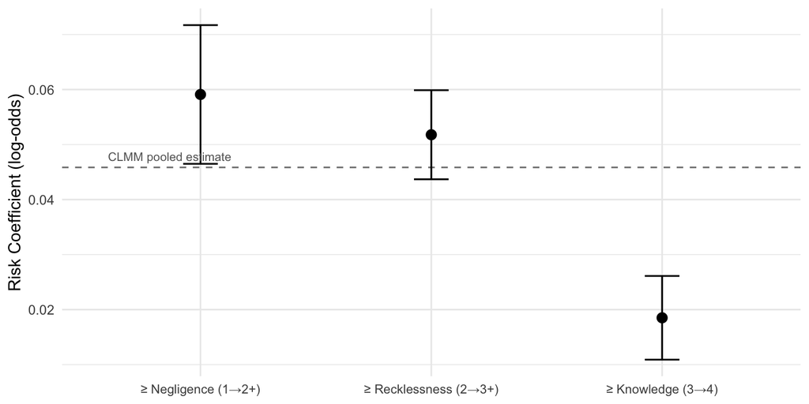

```r
# ── Visualize the proportional odds check ──
threshold_coefs %>%
  mutate(Threshold = factor(Threshold, levels = Threshold)) %>%
  ggplot(aes(x = Threshold, y = b_risk)) +
  geom_hline(yintercept = coef(m_risk)["slider_value"],
             linetype = "dashed", color = "grey50") +
  geom_errorbar(aes(ymin = ci_lo, ymax = ci_hi), width = 0.15, linewidth = 0.6) +
  geom_point(size = 3) +
  annotate("text", x = 0.6, y = coef(m_risk)["slider_value"],
           label = "CLMM pooled estimate", hjust = 0, vjust = -0.8,
           size = 3, color = "grey40") +
  labs(x = NULL, y = "Risk Coefficient (log-odds)") +
  theme_minimal(base_size = 12) +
  theme(axis.text.x = element_text(size = 9))
```

## 6.2 ROC Analysis for Threshold Models

As suggested during review, we compute ROC curves and AUC values for each threshold-specific logistic model. This provides a complementary measure of how well the risk slider discriminates at each transition point.

```r
# ── ROC curves for each threshold model ──
# Extract predicted probabilities from each threshold-specific GLMM.
d$pred_t1 <- predict(m_t1, type = "response")
d$pred_t2 <- predict(m_t2, type = "response")
d$pred_t3 <- predict(m_t3, type = "response")

roc_t1 <- roc(d$y_ge2, d$pred_t1, quiet = TRUE)
roc_t2 <- roc(d$y_ge3, d$pred_t2, quiet = TRUE)
roc_t3 <- roc(d$y_ge4, d$pred_t3, quiet = TRUE)

cat("── AUC by threshold ──\n")
```

```
## ── AUC by threshold ──
```

```r
cat("≥ Negligence (B vs. N+):    AUC =", fmt_num(auc(roc_t1), 3), "\n")
```

```
## ≥ Negligence (B vs. N+):    AUC = 0.926
```

```r
cat("≥ Recklessness (N- vs. R+): AUC =", fmt_num(auc(roc_t2), 3), "\n")
```

```
## ≥ Recklessness (N- vs. R+): AUC = 0.877
```

```r
cat("≥ Knowledge (R- vs. K):     AUC =", fmt_num(auc(roc_t3), 3), "\n")
```

```
## ≥ Knowledge (R- vs. K):     AUC = 0.859
```

```r
cat("\nAUC declines at the Knowledge threshold, consistent with the\n")
```

```
##
## AUC declines at the Knowledge threshold, consistent with the
```

```r
cat("proportional odds violation and the H4 risk reversal.\n")
```

```
## proportional odds violation and the H4 risk reversal.
```

## 6.3 Vignette Feature Balance

The minimization algorithm should produce roughly balanced factor levels. We verify this here.

```r
# ── Check that each binary feature is approximately 50/50 ──
balance_table <- d %>%
  summarise(across(c(source_bin, package_bin, inquiry_bin,
                     payment_bin, location_bin, contents_bin),
                   ~ mean(.x) * 100)) %>%
  pivot_longer(everything(), names_to = "Feature", values_to = "Pct_Level_1") %>%
  mutate(
    Feature = recode(Feature,
      "source_bin"   = "Source (biker)",
      "package_bin"  = "Package (duffel bag)",
      "inquiry_bin"  = "Inquiry (source tells)",
      "payment_bin"  = "Payment ($1000)",
      "location_bin" = "Location (Mexico)",
      "contents_bin" = "Contents (fentanyl)"
    ),
    Pct_Level_0 = 100 - Pct_Level_1
  )

balance_table %>%
  kable(digits = 1, col.names = c("Feature", "% Level 1", "% Level 0"),
        caption = "Feature balance (ideal: 50/50)") %>%
  kable_styling(bootstrap_options = c("striped", "condensed"), full_width = FALSE)
```

Feature balance (ideal: 50/50)

| Feature | % Level 1 | % Level 0 |
| --- | --- | --- |
| Source (biker) | 49.2 | 50.8 |
| Package (duffel bag) | 50.7 | 49.3 |
| Inquiry (source tells) | 49.4 | 50.6 |
| Payment ($1000) | 50.8 | 49.2 |
| Location (Mexico) | 49.9 | 50.1 |
| Contents (fentanyl) | 50.2 | 49.8 |

# 7 Publication-Quality Figures

```r
# ── Global theme for publication figures ──
theme_pub <- theme_minimal(base_size = 12) +
  theme(
    panel.grid.minor = element_blank(),
    panel.grid.major.x = element_blank(),
    axis.line = element_line(color = "black", linewidth = 0.3),
    axis.ticks = element_line(color = "black", linewidth = 0.3),
    legend.position = "bottom",
    plot.margin = margin(10, 10, 10, 10)
  )
```

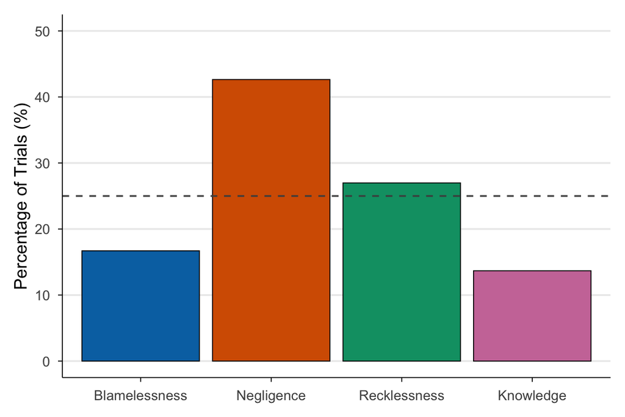

```r
# ── Figure 1: Judgment distribution ──
fig1_base <- d %>%
  mutate(judgment = factor(judgment,
    levels = c("Blamelessness","Negligence","Recklessness","Knowledge"))) %>%
  count(judgment) %>%
  mutate(pct = n / sum(n) * 100)

fig1_color <- ggplot(fig1_base, aes(x = judgment, y = pct, fill = judgment)) +
  geom_col(color = "black", linewidth = 0.3) +
  geom_hline(yintercept = 25, linetype = "dashed", color = "grey30") +
  scale_fill_manual(values = judgment_colors, guide = "none") +
  labs(x = NULL, y = "Percentage of Trials (%)") +
  scale_y_continuous(limits = c(0, 50), breaks = seq(0, 50, 10)) +
  theme_pub

fig1_bw <- ggplot(fig1_base, aes(x = judgment, y = pct, fill = judgment)) +
  geom_col(color = "black", linewidth = 0.3) +
  geom_hline(yintercept = 25, linetype = "dashed", color = "grey30") +
  scale_fill_manual(values = judgment_grays, guide = "none") +
  labs(x = NULL, y = "Percentage of Trials (%)") +
  scale_y_continuous(limits = c(0, 50), breaks = seq(0, 50, 10)) +
  theme_pub

fig1_color
```

```r
save_dual(fig1_color, fig1_bw, "fig1_judgment_distribution", 6, 4)
```

```
## Saved: fig1_judgment_distribution.pdf and fig1_judgment_distribution_bw.pdf
```

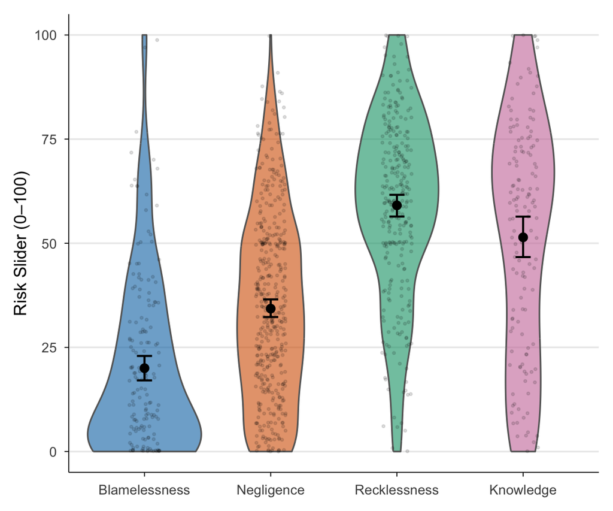

```r
# ── Figure 2: Risk slider distribution by mental state ──
# NOTE: Error bars are bootstrapped 95% CIs (mean_cl_boot), which may be
# slightly asymmetric around the mean. This is expected and correct behavior
# for bootstrapped intervals, not a rendering artifact.
fig2_base <- d %>%
  mutate(judgment = factor(judgment,
    levels = c("Blamelessness","Negligence","Recklessness","Knowledge")))

fig2_color <- ggplot(fig2_base, aes(x = judgment, y = slider_value, fill = judgment)) +
  geom_violin(color = "grey40", alpha = 0.6) +
  geom_jitter(width = 0.12, alpha = 0.12, size = 0.6, color = "black") +
  stat_summary(fun = mean, geom = "point", size = 2.5, color = "black") +
  stat_summary(fun.data = mean_cl_boot, geom = "errorbar",
               width = 0.12, linewidth = 0.7) +
  scale_fill_manual(values = judgment_colors, guide = "none") +
  labs(x = NULL, y = "Risk Slider (0–100)") +
  scale_y_continuous(limits = c(0, 100), breaks = seq(0, 100, 25)) +
  theme_pub

fig2_bw <- ggplot(fig2_base, aes(x = judgment, y = slider_value, fill = judgment)) +
  geom_violin(color = "grey40", alpha = 0.6) +
  geom_jitter(width = 0.12, alpha = 0.12, size = 0.6, color = "black") +
  stat_summary(fun = mean, geom = "point", size = 2.5, color = "black") +
  stat_summary(fun.data = mean_cl_boot, geom = "errorbar",
               width = 0.12, linewidth = 0.7) +
  scale_fill_manual(values = judgment_grays, guide = "none") +
  labs(x = NULL, y = "Risk Slider (0–100)") +
  scale_y_continuous(limits = c(0, 100), breaks = seq(0, 100, 25)) +
  theme_pub

fig2_color
```

```r
save_dual(fig2_color, fig2_bw, "fig2_risk_by_judgment", 6, 5)
```

```
## Saved: fig2_risk_by_judgment.pdf and fig2_risk_by_judgment_bw.pdf
```

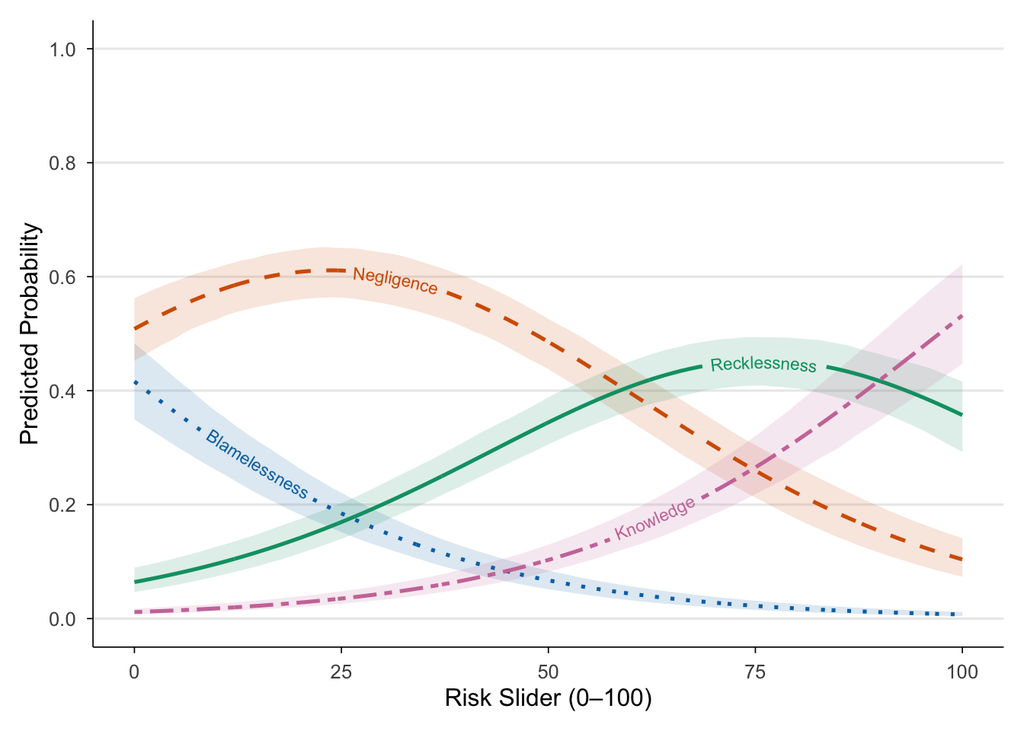

```r
# ── Figure 3: Predicted probability curves from CLMM with 95% CIs ──
# Uses color + linetype for online/print compatibility, plus geom_textpath
# labels directly on curves per Jaime's suggestion.
# Each label is placed at a different hjust to avoid the crossing zone.

# Label placement: position each label where its curve has breathing room.
#   Blamelessness peaks left  → label early (hjust 0.12)
#   Negligence peaks ~30      → label at 0.28
#   Recklessness peaks ~75    → label at 0.72
#   Knowledge rises right     → label late (0.88)
label_hjust <- c(
  "Blamelessness" = 0.12,
  "Negligence"    = 0.28,
  "Recklessness"  = 0.80,
  "Knowledge"     = 0.60
)

# Helper to build the plot with a given color palette
build_fig3 <- function(color_pal) {
  p <- ggplot(pred_with_ci, aes(x = slider, y = probability,
                                 color = judgment, linetype = judgment)) +
    geom_ribbon(aes(ymin = ci_lo, ymax = ci_hi, fill = judgment, group = judgment),
                alpha = 0.15, color = NA)

  # Add each curve's label at its own position
  for (j in names(label_hjust)) {
    p <- p + geom_textpath(
      data = pred_with_ci %>% filter(judgment == j),
      aes(label = judgment), linewidth = 0.9,
      size = 3, hjust = label_hjust[j], text_smoothing = 50
    )
  }

  p + scale_color_manual(values = color_pal) +
    scale_fill_manual(values = color_pal) +
    scale_linetype_manual(values = judgment_linetypes) +
    labs(x = "Risk Slider (0–100)", y = "Predicted Probability") +
    scale_y_continuous(limits = c(0, 1), breaks = seq(0, 1, 0.2)) +
    scale_x_continuous(breaks = seq(0, 100, 25)) +
    guides(color = "none", fill = "none", linetype = "none") +
    theme_pub
}

fig3_color <- build_fig3(judgment_colors)
fig3_bw    <- build_fig3(judgment_grays)

fig3_color
```

```r
save_dual(fig3_color, fig3_bw, "fig3_predicted_probabilities", 7, 5)
```

```
## Saved: fig3_predicted_probabilities.pdf and fig3_predicted_probabilities_bw.pdf
```

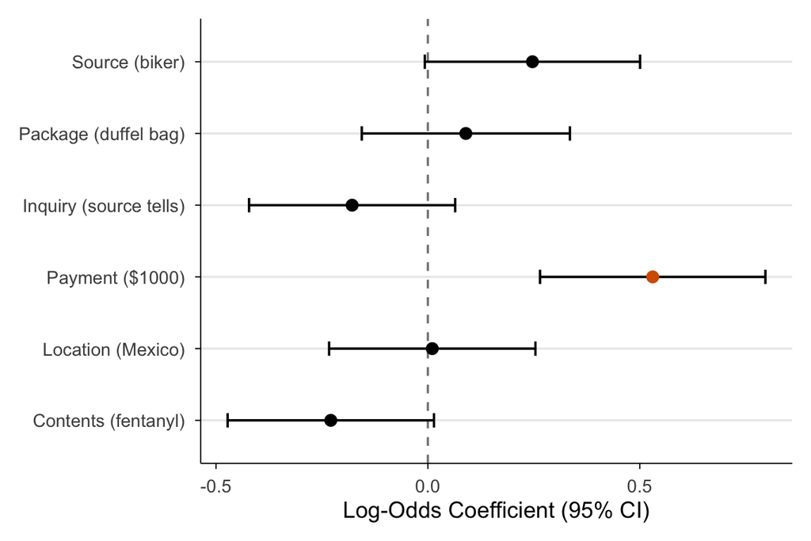

```r
# ── Figure 4: Forest plot of feature effects ──
# Color version: highlight significant predictors
fig4_color <- forest_data %>%
  mutate(sig_flag = ifelse(p_holm < .05, "Significant", "Not significant")) %>%
  ggplot(aes(x = b, y = Predictor)) +
  geom_vline(xintercept = 0, linetype = "dashed", color = "grey50") +
  geom_errorbarh(aes(xmin = ci_lo, xmax = ci_hi), height = 0.2, linewidth = 0.6) +
  geom_point(aes(color = sig_flag), size = 2.5) +
  scale_color_manual(values = c("Significant" = "#D55E00", "Not significant" = "black"),
                     guide = "none") +
  labs(x = "Log-Odds Coefficient (95% CI)", y = NULL) +
  theme_pub

fig4_bw <- forest_data %>%
  ggplot(aes(x = b, y = Predictor)) +
  geom_vline(xintercept = 0, linetype = "dashed", color = "grey50") +
  geom_errorbarh(aes(xmin = ci_lo, xmax = ci_hi), height = 0.2, linewidth = 0.6) +
  geom_point(size = 2.5) +
  labs(x = "Log-Odds Coefficient (95% CI)", y = NULL) +
  theme_pub

fig4_color
```

```r
save_dual(fig4_color, fig4_bw, "fig4_forest_plot", 6, 4)
```

```
## Saved: fig4_forest_plot.pdf and fig4_forest_plot_bw.pdf
```

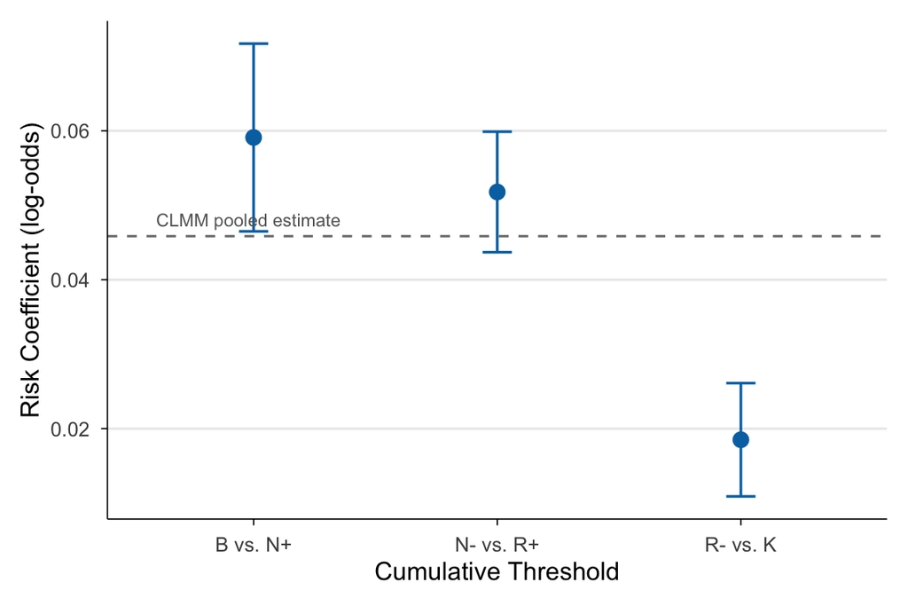

```r
# ── Figure 5: Proportional odds diagnostic ──
fig5_data <- threshold_coefs %>%
  mutate(Threshold = factor(
    c("B vs. N+", "N- vs. R+", "R- vs. K"),
    levels = c("B vs. N+", "N- vs. R+", "R- vs. K")))

fig5_color <- ggplot(fig5_data, aes(x = Threshold, y = b_risk)) +
  geom_hline(yintercept = coef(m_risk)["slider_value"],
             linetype = "dashed", color = "grey50") +
  geom_errorbar(aes(ymin = ci_lo, ymax = ci_hi), width = 0.12, linewidth = 0.6,
                color = "#0072B2") +
  geom_point(size = 3, color = "#0072B2") +
  annotate("text", x = 0.6, y = coef(m_risk)["slider_value"],
           label = "CLMM pooled estimate", hjust = 0, vjust = -0.8,
           size = 3, color = "grey40") +
  labs(x = "Cumulative Threshold", y = "Risk Coefficient (log-odds)") +
  theme_pub

fig5_bw <- ggplot(fig5_data, aes(x = Threshold, y = b_risk)) +
  geom_hline(yintercept = coef(m_risk)["slider_value"],
             linetype = "dashed", color = "grey50") +
  geom_errorbar(aes(ymin = ci_lo, ymax = ci_hi), width = 0.12, linewidth = 0.6) +
  geom_point(size = 3) +
  annotate("text", x = 0.6, y = coef(m_risk)["slider_value"],
           label = "CLMM pooled estimate", hjust = 0, vjust = -0.8,
           size = 3, color = "grey40") +
  labs(x = "Cumulative Threshold", y = "Risk Coefficient (log-odds)") +
  theme_pub

fig5_color
```

```r
save_dual(fig5_color, fig5_bw, "fig5_proportional_odds", 6, 4)
```

```
## Saved: fig5_proportional_odds.pdf and fig5_proportional_odds_bw.pdf
```

# 8 Summary

```r
# ── Bring all hypothesis results into one table ──

# For H2, report both CLMM z and ρ for completeness.
h2_test_str <- paste0("CLMM z = ", fmt_num(risk_z, 2),
                       "; ρ = ", fmt_num(rho_test$estimate, 3))
h2_es_str   <- paste0("OR/10pt = ", fmt_num(exp(risk_b * 10), 3),
                       "; β_std = ", fmt_num(risk_b_std, 3))

# For H3, report the CLMM z for payment.
h3_z   <- summary(m_full)$coefficients["payment_bin", "z value"]
h3_p   <- summary(m_full)$coefficients["payment_bin", "Pr(>|z|)"]
h3_d   <- summary(m_full)$coefficients["payment_bin", "Estimate"] * sqrt(3) / pi
h3_or  <- exp(summary(m_full)$coefficients["payment_bin", "Estimate"])

# For H4, report two-tailed p since the effect is reversed.
h4_test_str <- paste0("t = ", fmt_num(t_val, 2),
                       "; d = ", fmt_num(cohens_d_rk, 3))

summary_results <- tribble(
  ~Hypothesis, ~Test, ~`Effect Size`, ~p, ~Decision,

  "H1: Non-uniform",
  paste0("χ²(3) = ", round(chi_adj, 1), " (DEFF-adj)"),
  paste0("w = ", fmt_num(as.numeric(cohens_w), 3)),
  fmt_p(p_adj),
  "Supported",

  "H2: Risk–culpability",
  h2_test_str,
  h2_es_str,
  fmt_p(risk_p),
  "Supported",

  "H3: Payment bias",
  paste0("z = ", fmt_num(h3_z, 2)),
  paste0("d ≈ ", fmt_num(h3_d, 3), "; OR = ", fmt_num(h3_or, 3)),
  fmt_p(h3_p),
  "Supported",

  "H4: R vs. K (exploratory)",
  h4_test_str,
  paste0("b = ", fmt_num(rk_coef["Estimate"], 2)),
  fmt_p(p_two_tailed),
  "Reversed (K < R)"
)

summary_results %>%
  kable(caption = "Summary of hypothesis tests") %>%
  kable_styling(bootstrap_options = c("striped", "condensed"), full_width = FALSE)
```

Summary of hypothesis tests

| Hypothesis | Test | Effect Size | p | Decision |
| --- | --- | --- | --- | --- |
| H1: Non-uniform | χ²(3) = 131.7 (DEFF-adj) | w = 0.453 | < .001 | Supported |
| H2: Risk–culpability | CLMM z = 14.87; ρ = 0.480 | OR/10pt = 1.582; β_std = 1.241 | < .001 | Supported |
| H3: Payment bias | z = 3.91 | d ≈ 0.293; OR = 1.700 | < .001 | Supported |
| H4: R vs. K (exploratory) | t = -3.06; d = -0.281 | b = -6.96 | = .002 | Reversed (K < R) |

```r
# ── Save publication figures to a designated folder ──
cat("Publication figures saved (color + grayscale pairs):\n")
```

```
## Publication figures saved (color + grayscale pairs):
```

```r
cat("  fig1_judgment_distribution.pdf / _bw.pdf\n")
```

```
##   fig1_judgment_distribution.pdf / _bw.pdf
```

```r
cat("  fig2_risk_by_judgment.pdf / _bw.pdf\n")
```

```
##   fig2_risk_by_judgment.pdf / _bw.pdf
```

```r
cat("  fig3_predicted_probabilities.pdf / _bw.pdf\n")
```

```
##   fig3_predicted_probabilities.pdf / _bw.pdf
```

```r
cat("  fig4_forest_plot.pdf / _bw.pdf\n")
```

```
##   fig4_forest_plot.pdf / _bw.pdf
```

```r
cat("  fig5_proportional_odds.pdf / _bw.pdf\n")
```

```
##   fig5_proportional_odds.pdf / _bw.pdf
```